# ETM 58D Business Analytics Project

Sena Torlak

2022-06-12

**Solar Power Forecasting**

ETM 58D Business Analytics Project *by Sena Torlak*

**Table of Content**

1. Introduction
2. Setup & Library
3. Descriptive Analysis
4. Data Manipulation
5. Modelling
6. Prediction for the Test Period
7. Possible Extensions

#Introduction

*Problem description*

In this project, it is aimed to make an hourly solar energy forecast for the next day with KIVANC 2 SPP (Solar Power Plant). KIVANÇ 2 SPP is located in Mersin (between 36-37° north latitude and 33-35° east longitude) and detailed information about capacity and location can be found at . [their site](https://www.kivancenerji.com.tr/kivanc2ges.html).

*Assumption and approach*

The forecast can be used in real life needs of energy traders operating in energy markets. The assumption in this project is that on day d, forecasts are needed for day d+1 and you know the production values by the end of day d-1. In real life, forecasts for the next day (i.e. d+1) should be sent before 12:00 on day d.

*Descriptive analysis of the given data*

Provided dataset for the prediction includes the weather measurements for 9 grid points (coordinates) nearby the power plant. The weather variables that can help for solar power plant production forecasting are TEMP (Temperature at the provided location), REL_HUMIDITY (Relative humidity at the provided location), DSWRF (The short version of downward shortwave radiation flux), CLOUD_LOW_LAYER (Total cloud cover data in terms of percentage for low-level type of clouds). When checked, it was observed that there were no missing values in the date and hours data.

#Setup & Library

```r
#install.packages("tidyverse")
#install.packages("lubridate")
#install.packages("readxl")
#install.packages("skimr")
#install.packages("magrittr")
#install.packages("tidyquant")
#install.packages("tsibble")
#install.packages("feasts")
#install.packages("ggcorrplot")
#install.packages("glmnet")
#install.packages("caret")
#install.packages("rattle")
#install.packages("data.table")
#install.packages("reshape")

library(tidyverse)
library(lubridate)
library(readxl)
library(skimr)
library(magrittr)
library(tidyquant)
library(tsibble)
library(feasts)
library(ggcorrplot)
library(glmnet)
library(caret)
library(rattle)
library(data.table)
library(reshape)

set.seed(1234)
```

#Import Data Hourly solar power plan production data is imported from csv file.

```r
production=fread("C:/Users/user/Documents/GitHub/spring22-senatorlakk/Project/production.csv")
weather=fread("C:/Users/user/Documents/GitHub/spring22-senatorlakk/Project/long_weather.csv")

head(production)
```

```
##          date hour production
## 1: 2021-02-01    0          0
## 2: 2021-02-01    1          0
## 3: 2021-02-01    2          0
## 4: 2021-02-01    3          0
## 5: 2021-02-01    4          0
## 6: 2021-02-01    5          0
```

```r
head(weather)
```

```
##          date hour   lat lon variable value
## 1: 2021-02-01    0 36.25  33    DSWRF     0
## 2: 2021-02-01    1 36.25  33    DSWRF     0
## 3: 2021-02-01    2 36.25  33    DSWRF     0
## 4: 2021-02-01    3 36.25  33    DSWRF     0
## 5: 2021-02-01    4 36.25  33    DSWRF     0
## 6: 2021-02-01    5 36.25  33    DSWRF     0
```

```r
production[,timestamp:=as.Date(date)+dhours(hour)]
head(production)
```

```
##          date hour production           timestamp
## 1: 2021-02-01    0          0 2021-02-01 00:00:00
## 2: 2021-02-01    1          0 2021-02-01 01:00:00
## 3: 2021-02-01    2          0 2021-02-01 02:00:00
## 4: 2021-02-01    3          0 2021-02-01 03:00:00
## 5: 2021-02-01    4          0 2021-02-01 04:00:00
## 6: 2021-02-01    5          0 2021-02-01 05:00:00
```

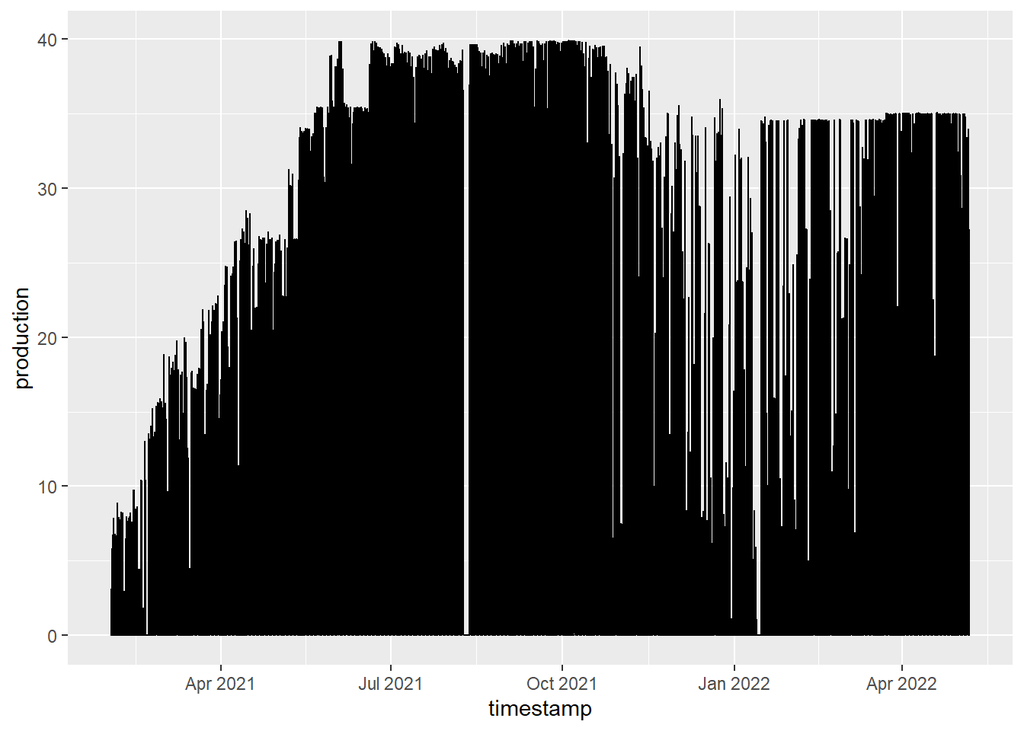

```r
ggplot(production,aes(x=timestamp,y=production)) + geom_line()
```

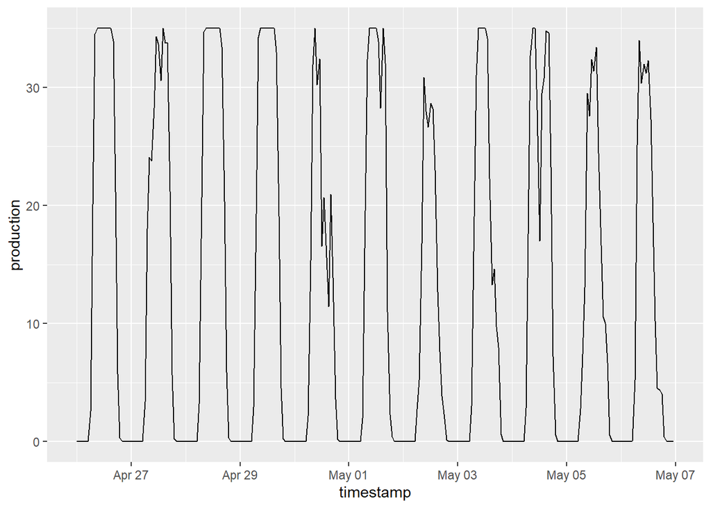

```r
ggplot(production[date>'2022-04-25'],aes(x=timestamp,y=production)) + geom_line()
```

```r
weather[,.N,list(lat,lon)]
```

```
##      lat   lon     N
## 1: 36.25 33.00 44832
## 2: 36.25 33.25 44832
## 3: 36.25 33.50 44832
## 4: 36.50 33.00 44832
## 5: 36.50 33.25 44832
## 6: 36.50 33.50 44832
## 7: 36.75 33.00 44832
## 8: 36.75 33.25 44832
## 9: 36.75 33.50 44832
```

```r
weather[,.N,list(variable)]
```

```
##           variable      N
## 1:           DSWRF 100872
## 2:    REL_HUMIDITY 100872
## 3: CLOUD_LOW_LAYER 100872
## 4:            TEMP 100872
```

```r
dswrf=weather[variable=='DSWRF' & lat==36.5 & lon==33.25]
dswrf[,timestamp:=as.Date(date)+dhours(hour)]
head(dswrf)
```

```
##          date hour  lat   lon variable value           timestamp
## 1: 2021-02-01    0 36.5 33.25    DSWRF     0 2021-02-01 00:00:00
## 2: 2021-02-01    1 36.5 33.25    DSWRF     0 2021-02-01 01:00:00
## 3: 2021-02-01    2 36.5 33.25    DSWRF     0 2021-02-01 02:00:00
## 4: 2021-02-01    3 36.5 33.25    DSWRF     0 2021-02-01 03:00:00
## 5: 2021-02-01    4 36.5 33.25    DSWRF     0 2021-02-01 04:00:00
## 6: 2021-02-01    5 36.5 33.25    DSWRF     0 2021-02-01 05:00:00
```

Production values have a continues trend related to timestamp.

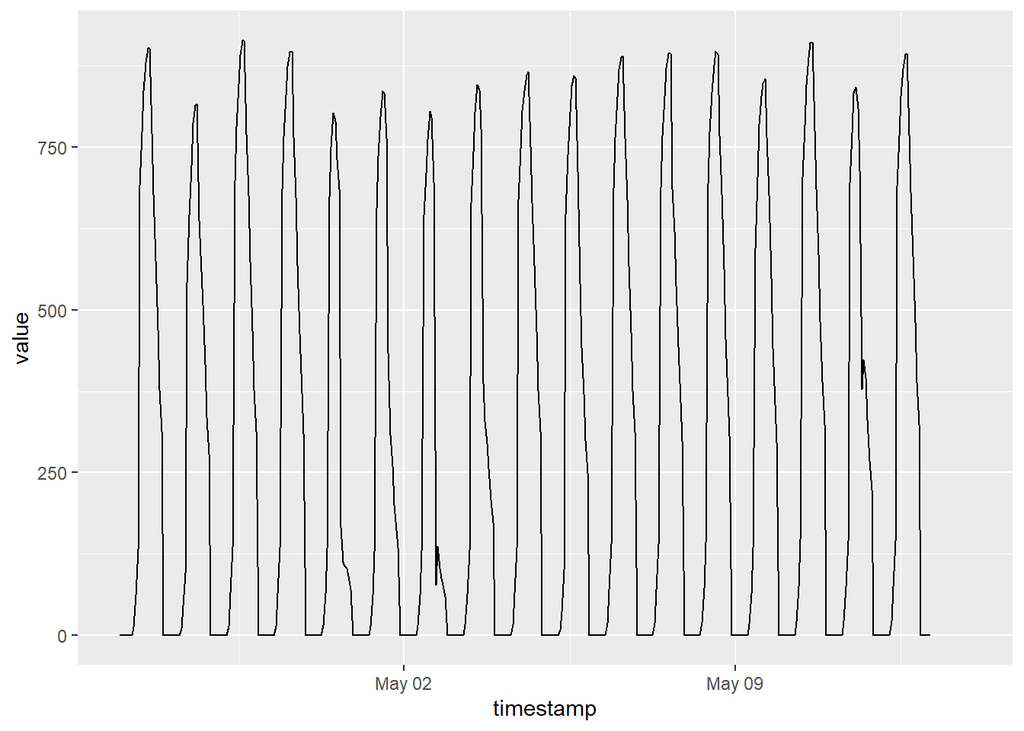

```r
ggplot(dswrf[date>'2022-04-25'],aes(x=timestamp,y=value)) + geom_line() + geom_line()
```

```r
wide_weather=dcast(weather,date+hour~variable+lat+lon,value.var='value')

str(wide_weather)
```

```
## Classes 'data.table' and 'data.frame':   11208 obs. of  38 variables:
##  $ date                       : IDate, format: "2021-02-01" "2021-02-01" ...
##  $ hour                       : int  0 1 2 3 4 5 6 7 8 9 ...
##  $ CLOUD_LOW_LAYER_36.25_33   : num  45 44 37 43 72 69 75 79 83 86 ...
##  $ CLOUD_LOW_LAYER_36.25_33.25: num  31 26 35 45 95 95 96 97 97 97 ...
##  $ CLOUD_LOW_LAYER_36.25_33.5 : num  3 19 35 46 46 31 53 65 60 67 ...
##  $ CLOUD_LOW_LAYER_36.5_33    : num  53 64 60 51 16 24 21 16 13 20 ...
##  $ CLOUD_LOW_LAYER_36.5_33.25 : num  10 21 19 24 57 68 63 72 78 78 ...
##  $ CLOUD_LOW_LAYER_36.5_33.5  : num  0 0 0 8 1 2 14 36 46 43 ...
##  $ CLOUD_LOW_LAYER_36.75_33   : num  92 93 92 91 86 86 86 87 87 87 ...
##  $ CLOUD_LOW_LAYER_36.75_33.25: num  26 31 35 36 40 56 64 69 75 78 ...
##  $ CLOUD_LOW_LAYER_36.75_33.5 : num  0 0 1 9 36 50 63 72 77 77 ...
##  $ DSWRF_36.25_33             : num  0 0 0 0 0 0 0 0 0 3 ...
##  $ DSWRF_36.25_33.25          : num  0 0 0 0 0 0 0 0 0 2 ...
##  $ DSWRF_36.25_33.5           : num  0 0 0 0 0 0 0 0 0 3 ...
```

[output cut: 26 more lines]

```r
str(production)
```

```
## Classes 'data.table' and 'data.frame':   10896 obs. of  4 variables:
##  $ date      : IDate, format: "2021-02-01" "2021-02-01" ...
##  $ hour      : int  0 1 2 3 4 5 6 7 8 9 ...
##  $ production: num  0 0 0 0 0 0 0 0 0.189 1.35 ...
##  $ timestamp : POSIXct, format: "2021-02-01 00:00:00" "2021-02-01 01:00:00" ...
##  - attr(*, ".internal.selfref")=<externalptr>
```

Hourly Solar Production In order to understand the hourly solar production, descriptive analysis is conducted.

```r
skim(wide_weather)
```

Data summary

| Name | wide_weather |
| --- | --- |
| Number of rows | 11208 |
| Number of columns | 38 |
| Key | date, hour |
| _______________________ |  |
| Column type frequency: |  |
| Date | 1 |
| numeric | 37 |
| ________________________ |  |
| Group variables | None |

**Variable type: Date**

| skim_variable | n_missing | complete_rate | min | max | median | n_unique |
| --- | --- | --- | --- | --- | --- | --- |
| date | 0 | 1 | 2021-02-01 | 2022-05-13 | 2021-09-22 | 467 |

**Variable type: numeric**

| skim_variable | n_missing | complete_rate | mean | sd | p0 | p25 | p50 | p75 | p100 | hist |
| --- | --- | --- | --- | --- | --- | --- | --- | --- | --- | --- |
| hour | 0 | 1 | 11.50 | 6.92 | 0.00 | 5.75 | 11.50 | 17.25 | 23.00 | ▇▇▆▇▇ |
| CLOUD_LOW_LAYER_36.25_33 | 20 | 1 | 15.92 | 31.30 | 0.00 | 0.00 | 0.00 | 7.82 | 100.00 | ▇▁▁▁▁ |
| CLOUD_LOW_LAYER_36.25_33.25 | 20 | 1 | 15.02 | 30.14 | 0.00 | 0.00 | 0.00 | 7.60 | 100.00 | ▇▁▁▁▁ |
| CLOUD_LOW_LAYER_36.25_33.5 | 20 | 1 | 13.14 | 28.81 | 0.00 | 0.00 | 0.00 | 3.90 | 100.00 | ▇▁▁▁▁ |
| CLOUD_LOW_LAYER_36.5_33 | 20 | 1 | 15.82 | 30.82 | 0.00 | 0.00 | 0.00 | 8.50 | 100.00 | ▇▁▁▁▁ |
| CLOUD_LOW_LAYER_36.5_33.25 | 20 | 1 | 12.17 | 27.39 | 0.00 | 0.00 | 0.00 | 4.90 | 100.00 | ▇▁▁▁▁ |
| CLOUD_LOW_LAYER_36.5_33.5 | 20 | 1 | 10.12 | 25.38 | 0.00 | 0.00 | 0.00 | 2.00 | 100.00 | ▇▁▁▁▁ |
| CLOUD_LOW_LAYER_36.75_33 | 20 | 1 | 19.59 | 33.22 | 0.00 | 0.00 | 0.00 | 24.00 | 100.00 | ▇▁▁▁▁ |
| CLOUD_LOW_LAYER_36.75_33.25 | 20 | 1 | 12.37 | 26.44 | 0.00 | 0.00 | 0.00 | 7.00 | 100.00 | ▇▁▁▁▁ |
| CLOUD_LOW_LAYER_36.75_33.5 | 20 | 1 | 13.16 | 27.92 | 0.00 | 0.00 | 0.00 | 7.00 | 100.00 | ▇▁▁▁▁ |
| DSWRF_36.25_33 | 20 | 1 | 233.22 | 287.93 | 0.00 | 0.00 | 60.11 | 448.68 | 927.00 | ▇▂▂▂▁ |
| DSWRF_36.25_33.25 | 20 | 1 | 233.99 | 287.43 | 0.00 | 0.00 | 66.90 | 448.82 | 924.50 | ▇▂▂▂▁ |
| DSWRF_36.25_33.5 | 20 | 1 | 236.27 | 287.43 | 0.00 | 0.00 | 72.43 | 455.36 | 923.98 | ▇▂▂▂▁ |
| DSWRF_36.5_33 | 20 | 1 | 236.90 | 290.71 | 0.00 | 0.00 | 67.63 | 455.56 | 939.58 | ▇▂▂▂▁ |
| DSWRF_36.5_33.25 | 20 | 1 | 236.66 | 288.97 | 0.00 | 0.00 | 70.85 | 453.36 | 930.00 | ▇▂▂▂▁ |
| DSWRF_36.5_33.5 | 20 | 1 | 238.61 | 288.07 | 0.00 | 0.00 | 76.30 | 459.36 | 924.64 | ▇▂▂▂▁ |
| DSWRF_36.75_33 | 20 | 1 | 236.89 | 289.66 | 0.00 | 0.00 | 72.06 | 448.80 | 940.43 | ▇▂▂▂▁ |
| DSWRF_36.75_33.25 | 20 | 1 | 237.84 | 288.76 | 0.00 | 0.00 | 72.01 | 455.16 | 928.00 | ▇▂▂▂▁ |
| DSWRF_36.75_33.5 | 20 | 1 | 242.37 | 292.73 | 0.00 | 0.00 | 77.38 | 466.61 | 935.55 | ▇▂▂▂▁ |
| REL_HUMIDITY_36.25_33 | 20 | 1 | 52.97 | 21.44 | 9.30 | 36.10 | 49.70 | 67.60 | 100.00 | ▂▇▇▅▃ |
| REL_HUMIDITY_36.25_33.25 | 20 | 1 | 53.28 | 20.87 | 12.60 | 36.68 | 50.40 | 67.90 | 99.70 | ▃▇▇▃▃ |
| REL_HUMIDITY_36.25_33.5 | 20 | 1 | 52.13 | 20.40 | 12.30 | 35.88 | 49.60 | 66.60 | 99.20 | ▃▇▇▅▃ |
| REL_HUMIDITY_36.5_33 | 20 | 1 | 54.62 | 23.32 | 7.70 | 35.60 | 52.40 | 73.70 | 100.00 | ▃▇▇▆▅ |
| REL_HUMIDITY_36.5_33.25 | 20 | 1 | 50.82 | 21.89 | 6.80 | 33.20 | 48.40 | 67.00 | 100.00 | ▃▇▇▅▃ |
| REL_HUMIDITY_36.5_33.5 | 20 | 1 | 46.36 | 20.33 | 8.30 | 30.58 | 43.90 | 60.10 | 100.00 | ▅▇▆▃▂ |
| REL_HUMIDITY_36.75_33 | 20 | 1 | 58.11 | 24.07 | 9.40 | 37.68 | 56.70 | 79.40 | 100.00 | ▃▇▇▆▇ |
| REL_HUMIDITY_36.75_33.25 | 20 | 1 | 50.25 | 21.91 | 6.80 | 32.50 | 47.70 | 66.30 | 100.00 | ▃▇▇▅▃ |
| REL_HUMIDITY_36.75_33.5 | 20 | 1 | 52.53 | 21.68 | 10.30 | 34.70 | 50.65 | 69.40 | 100.00 | ▅▇▇▆▃ |
| TEMP_36.25_33 | 20 | 1 | 286.58 | 8.59 | 265.36 | 279.66 | 286.17 | 293.24 | 308.83 | ▂▇▇▆▂ |
| TEMP_36.25_33.25 | 20 | 1 | 287.58 | 8.45 | 267.97 | 280.87 | 287.00 | 294.12 | 309.86 | ▂▇▇▆▂ |
| TEMP_36.25_33.5 | 20 | 1 | 288.83 | 8.48 | 267.60 | 282.22 | 288.27 | 295.29 | 310.76 | ▂▇▇▆▂ |
| TEMP_36.5_33 | 20 | 1 | 283.89 | 9.52 | 257.23 | 276.72 | 283.81 | 290.97 | 307.18 | ▁▆▇▆▂ |
| TEMP_36.5_33.25 | 20 | 1 | 286.59 | 9.41 | 262.68 | 279.35 | 286.20 | 293.82 | 310.19 | ▂▇▇▆▂ |
| TEMP_36.5_33.5 | 20 | 1 | 289.63 | 9.51 | 267.24 | 282.38 | 288.97 | 296.80 | 314.99 | ▂▇▇▆▂ |
| TEMP_36.75_33 | 20 | 1 | 282.15 | 9.42 | 258.98 | 274.87 | 281.96 | 289.54 | 304.98 | ▂▇▇▇▂ |
| TEMP_36.75_33.25 | 20 | 1 | 286.59 | 9.51 | 263.67 | 279.26 | 286.23 | 293.94 | 310.40 | ▂▇▇▆▂ |
| TEMP_36.75_33.5 | 20 | 1 | 284.85 | 9.42 | 261.47 | 277.60 | 284.66 | 292.13 | 308.29 | ▂▇▇▇▂ |

```r
solarprodhourly = production %>%
  group_by(hour) %>%
  summarise(
    count = n(),
    mean_production = mean(production),
    min_production = min(production),
    max_production = max(production)
  )
solarprodhourly
```

```
## # A tibble: 24 × 5
##     hour count mean_production min_production max_production
##    <int> <int>           <dbl>          <dbl>          <dbl>
##  1     0   454          0                   0          0
##  2     1   454          0                   0          0
##  3     2   454          0                   0          0
##  4     3   454          0                   0          0
##  5     4   454          0                   0          0
##  6     5   454          0.0251              0          0.282
##  7     6   454          1.01                0          7.53
##  8     7   454          8.39                0         27.3
##  9     8   454         20.0                 0         39.3
## 10     9   454         26.0                 0         39.9
## # … with 14 more rows
```

Since there is no sunlight & production at night, data will be analyses between 05.00 am and 19.00 pm. (findings are based on histogram data.)

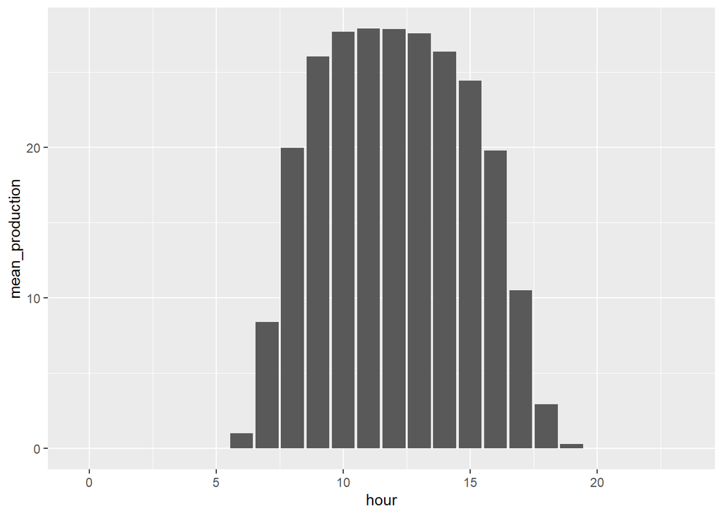

```r
ggplot(solarprodhourly, aes(x=hour, y=mean_production)) + geom_bar(stat = "identity")
```

So we can focus only to daytime.

```r
  daytime <- solarprodhourly %>% filter(hour >= 5 & hour <= 19)
  head(daytime, 20)
```

```
## # A tibble: 15 × 5
##     hour count mean_production min_production max_production
##    <int> <int>           <dbl>          <dbl>          <dbl>
##  1     5   454          0.0251          0              0.282
##  2     6   454          1.01            0              7.53
##  3     7   454          8.39            0             27.3
##  4     8   454         20.0             0             39.3
##  5     9   454         26.0             0             39.9
##  6    10   454         27.7             0             39.9
##  7    11   454         27.9             0.756         39.9
##  8    12   454         27.8             1.07          39.8
##  9    13   454         27.6             1.16          39.9
## 10    14   454         26.4             0.564         39.8
## 11    15   454         24.4             0             39.7
## 12    16   454         19.8             0             39.2
## 13    17   454         10.5             0             29.4
## 14    18   454          2.94            0             12.2
## 15    19   454          0.296           0              3.31
```

#Descriptive Analyses

In orer to understand how the independent and dependent variables are distributed over time and how tehy are related to each other below analysis handled.

##Independent Variables

Time series of independent variables are given below.

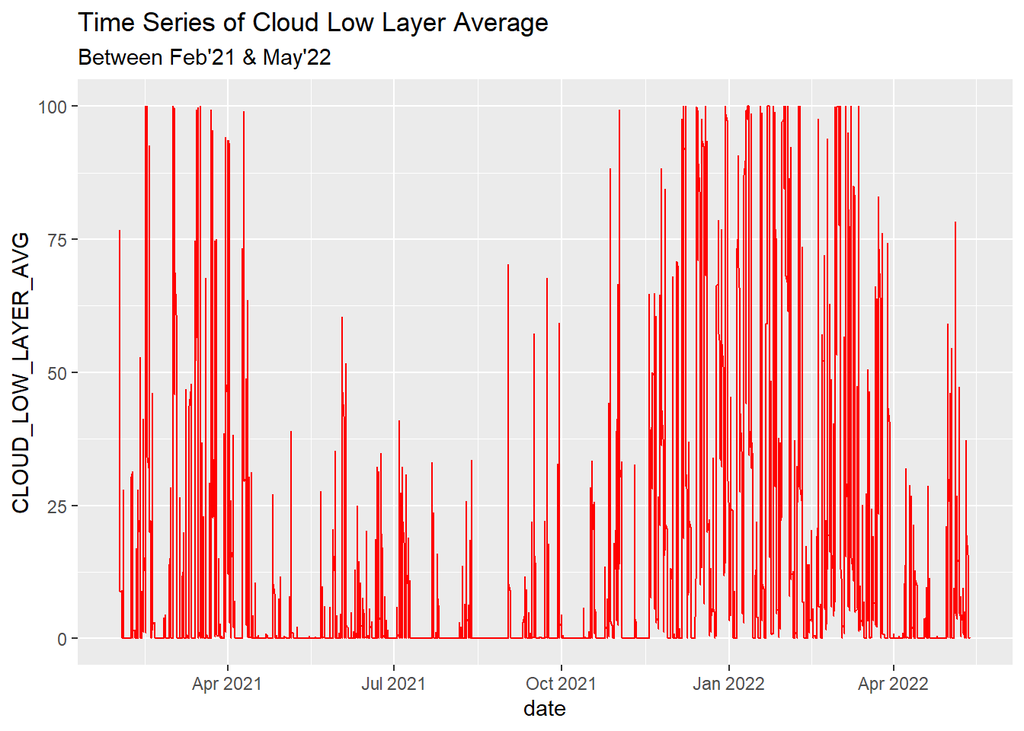

```r
wide_weather$CLOUD_LOW_LAYER_AVG=(wide_weather$CLOUD_LOW_LAYER_36.25_33+
              wide_weather$CLOUD_LOW_LAYER_36.25_33.25+wide_weather$CLOUD_LOW_LAYER_36.25_33.5+
              wide_weather$CLOUD_LOW_LAYER_36.5_33+wide_weather$CLOUD_LOW_LAYER_36.5_33.25+
              wide_weather$CLOUD_LOW_LAYER_36.5_33.5+wide_weather$CLOUD_LOW_LAYER_36.75_33+
              wide_weather$CLOUD_LOW_LAYER_36.75_33.25+wide_weather$CLOUD_LOW_LAYER_36.75_33.5)/9

wide_weather$DSWRF_AVG =(wide_weather$DSWRF_36.25_33+
              wide_weather$DSWRF_36.25_33.25+wide_weather$DSWRF_36.25_33.5+
              wide_weather$DSWRF_36.5_33+wide_weather$DSWRF_36.5_33.25+
              wide_weather$DSWRF_36.5_33.5+wide_weather$DSWRF_36.75_33+
              wide_weather$DSWRF_36.75_33.25+wide_weather$DSWRF_36.75_33.5)/9

wide_weather$TEMP_AVG  =(wide_weather$TEMP_36.25_33+
              wide_weather$TEMP_36.25_33.25+wide_weather$TEMP_36.25_33.5+
              wide_weather$TEMP_36.5_33+wide_weather$TEMP_36.5_33.25+
              wide_weather$TEMP_36.5_33.5+wide_weather$TEMP_36.75_33+
              wide_weather$TEMP_36.75_33.25+wide_weather$TEMP_36.75_33.5)/9

wide_weather$HUMD_AVG  =(wide_weather$REL_HUMIDITY_36.25_33+
              wide_weather$REL_HUMIDITY_36.25_33.25+wide_weather$REL_HUMIDITY_36.25_33.5+
              wide_weather$REL_HUMIDITY_36.5_33+wide_weather$REL_HUMIDITY_36.5_33.25+
              wide_weather$REL_HUMIDITY_36.5_33.5+wide_weather$REL_HUMIDITY_36.75_33+
              wide_weather$REL_HUMIDITY_36.75_33.25+wide_weather$REL_HUMIDITY_36.75_33.5)/9


ggplot(wide_weather,aes(x=date,y=CLOUD_LOW_LAYER_AVG))+
  geom_line(color="red")+
  ggtitle("Time Series of Cloud Low Layer Average",
          subtitle="Between Feb'21 & May'22")
```

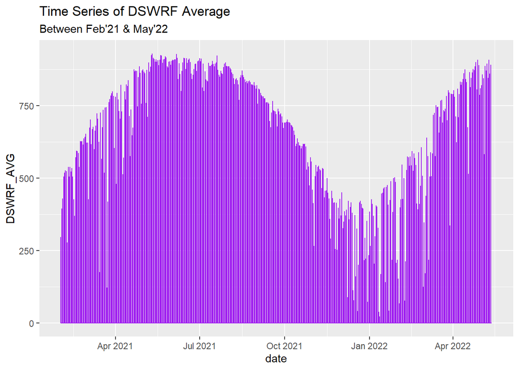

```r
ggplot(wide_weather,aes(x=date,y=DSWRF_AVG))+
  geom_line(color="purple")+
  ggtitle("Time Series of DSWRF Average",
          subtitle="Between Feb'21 & May'22")
```

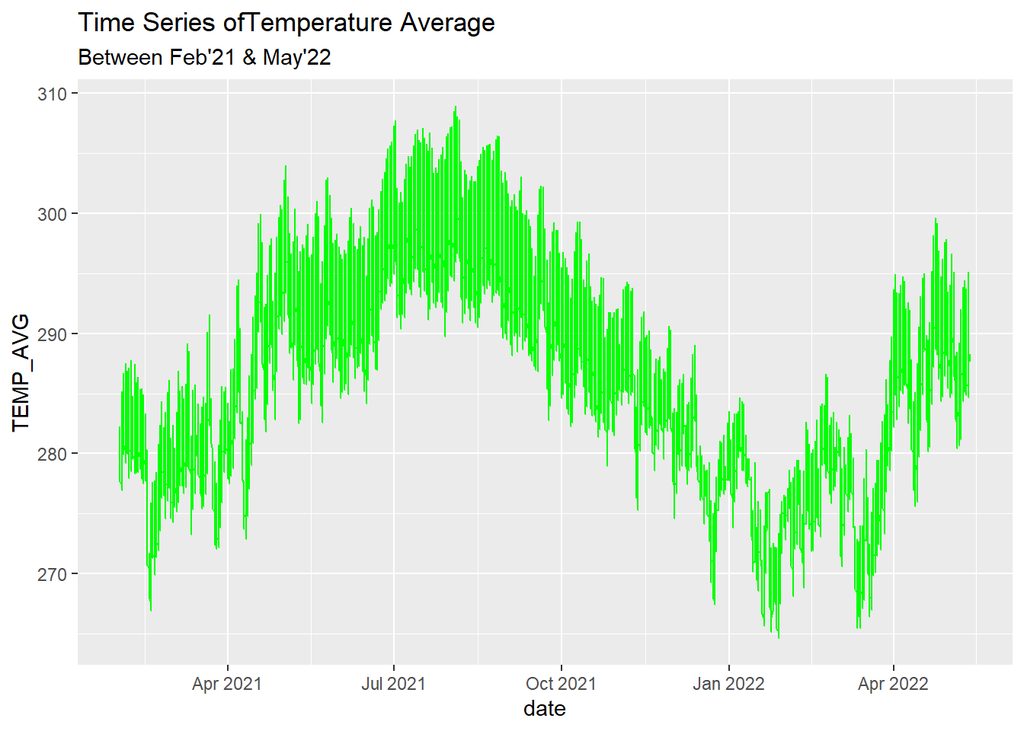

```r
ggplot(wide_weather,aes(x=date,y=TEMP_AVG))+
  geom_line(color="green")+
  ggtitle("Time Series ofTemperature Average ",
          subtitle="Between Feb'21 & May'22")
```

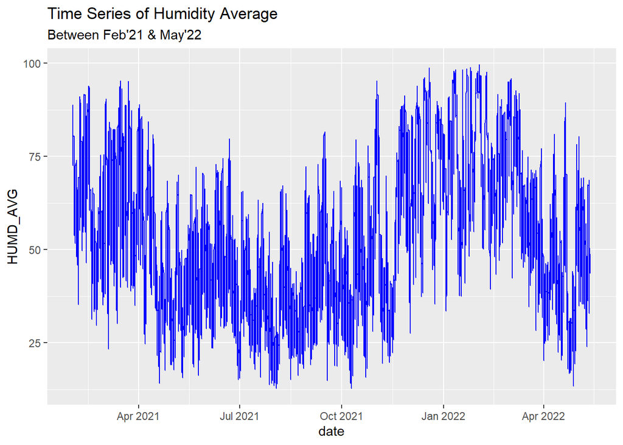

```r
ggplot(wide_weather,aes(x=date,y=HUMD_AVG))+
  geom_line(color="blue")+
  ggtitle("Time Series of Humidity Average",
          subtitle="Between Feb'21 & May'22")
```

```r
weathernew = wide_weather[,-(3:38)]
head(data.table(weathernew))
```

```
##          date hour CLOUD_LOW_LAYER_AVG DSWRF_AVG TEMP_AVG HUMD_AVG
## 1: 2021-02-01    0            28.88889         0 277.8989 88.87778
## 2: 2021-02-01    1            33.11111         0 277.8444 87.25556
## 3: 2021-02-01    2            34.88889         0 277.7413 85.56667
## 4: 2021-02-01    3            39.22222         0 277.8817 84.57778
## 5: 2021-02-01    4            49.88889         0 277.7742 85.32222
## 6: 2021-02-01    5            53.44444         0 277.6518 86.48889
```

```r
weathernew[,timestamp:=as.Date(date)+dhours(hour)]


weather_production <- production %>% full_join(weathernew,by="timestamp")
head(weather_production)
```

```
##        date.x hour.x production           timestamp     date.y hour.y
## 1: 2021-02-01      0          0 2021-02-01 00:00:00 2021-02-01      0
## 2: 2021-02-01      1          0 2021-02-01 01:00:00 2021-02-01      1
## 3: 2021-02-01      2          0 2021-02-01 02:00:00 2021-02-01      2
## 4: 2021-02-01      3          0 2021-02-01 03:00:00 2021-02-01      3
## 5: 2021-02-01      4          0 2021-02-01 04:00:00 2021-02-01      4
## 6: 2021-02-01      5          0 2021-02-01 05:00:00 2021-02-01      5
##    CLOUD_LOW_LAYER_AVG DSWRF_AVG TEMP_AVG HUMD_AVG
## 1:            28.88889         0 277.8989 88.87778
## 2:            33.11111         0 277.8444 87.25556
## 3:            34.88889         0 277.7413 85.56667
## 4:            39.22222         0 277.8817 84.57778
## 5:            49.88889         0 277.7742 85.32222
## 6:            53.44444         0 277.6518 86.48889
```

```r
weather_production <- weather_production %>% filter(hour.x >= 5 & hour.x <= 19)
  head(weather_production, 20)
```

```
##         date.x hour.x production           timestamp     date.y hour.y
##  1: 2021-02-01      5      0.000 2021-02-01 05:00:00 2021-02-01      5
##  2: 2021-02-01      6      0.000 2021-02-01 06:00:00 2021-02-01      6
##  3: 2021-02-01      7      0.000 2021-02-01 07:00:00 2021-02-01      7
##  4: 2021-02-01      8      0.189 2021-02-01 08:00:00 2021-02-01      8
##  5: 2021-02-01      9      1.350 2021-02-01 09:00:00 2021-02-01      9
##  6: 2021-02-01     10      1.730 2021-02-01 10:00:00 2021-02-01     10
##  7: 2021-02-01     11      2.730 2021-02-01 11:00:00 2021-02-01     11
##  8: 2021-02-01     12      1.950 2021-02-01 12:00:00 2021-02-01     12
##  9: 2021-02-01     13      1.350 2021-02-01 13:00:00 2021-02-01     13
## 10: 2021-02-01     14      2.040 2021-02-01 14:00:00 2021-02-01     14
## 11: 2021-02-01     15      3.150 2021-02-01 15:00:00 2021-02-01     15
## 12: 2021-02-01     16      5.830 2021-02-01 16:00:00 2021-02-01     16
## 13: 2021-02-01     17      1.350 2021-02-01 17:00:00 2021-02-01     17
## 14: 2021-02-01     18      0.000 2021-02-01 18:00:00 2021-02-01     18
```

[output cut: 27 more lines]

##Histograms of Target & Independent Variables

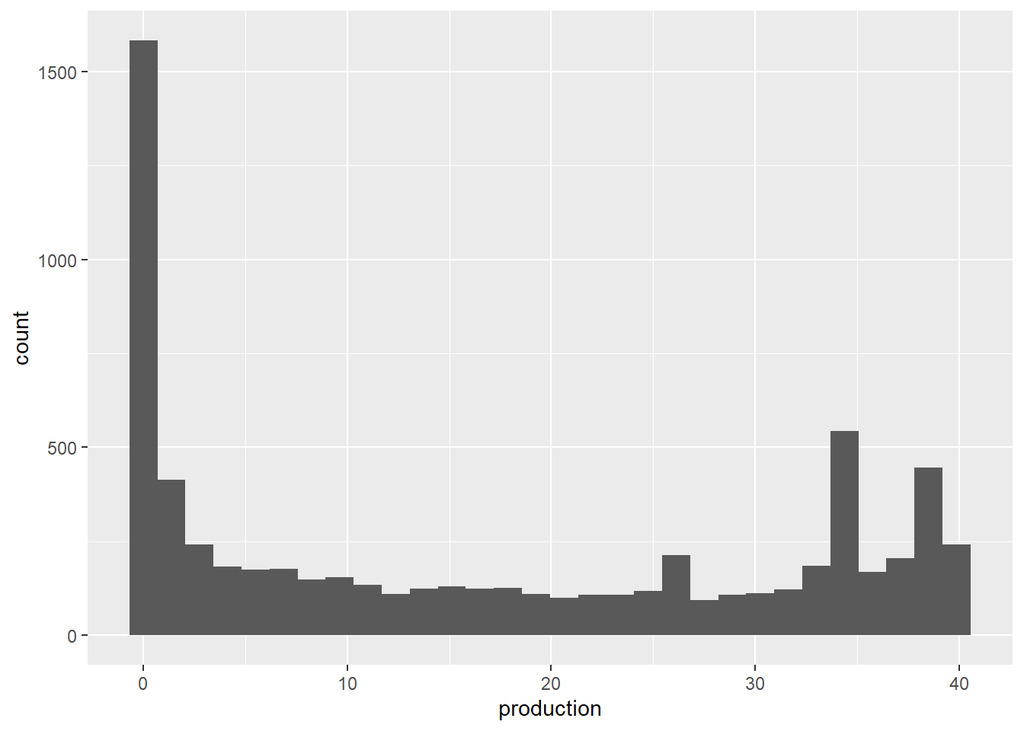

```r
ggplot(weather_production, aes(x=production)) + geom_histogram()
```

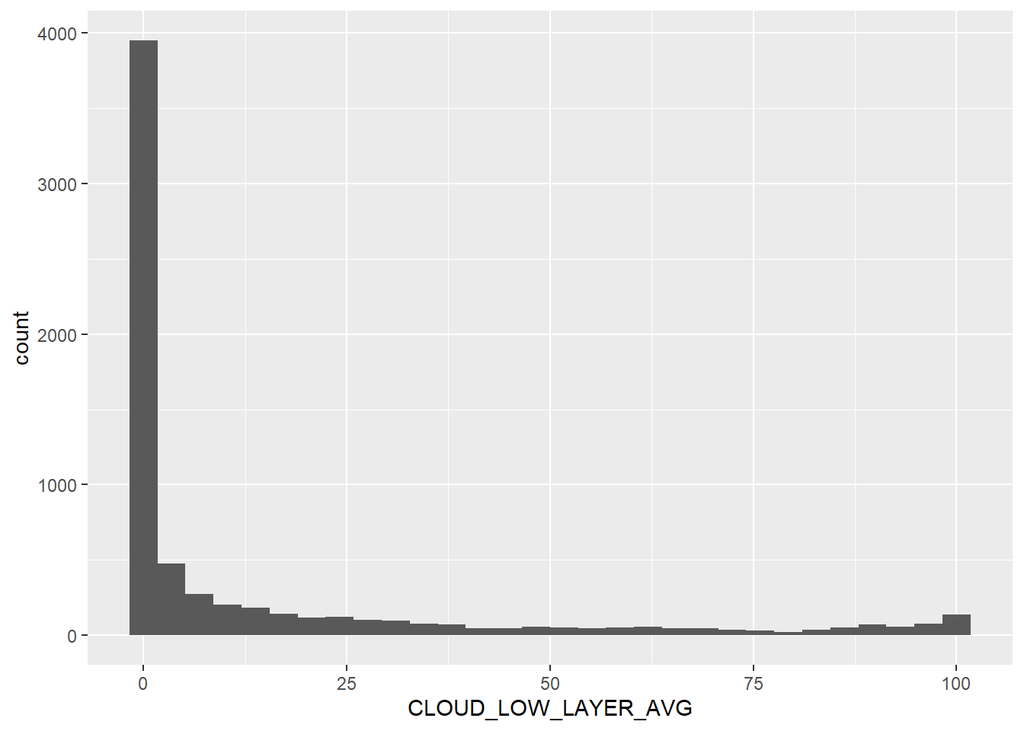

```r
ggplot(weather_production, aes(x=CLOUD_LOW_LAYER_AVG)) + geom_histogram()
```

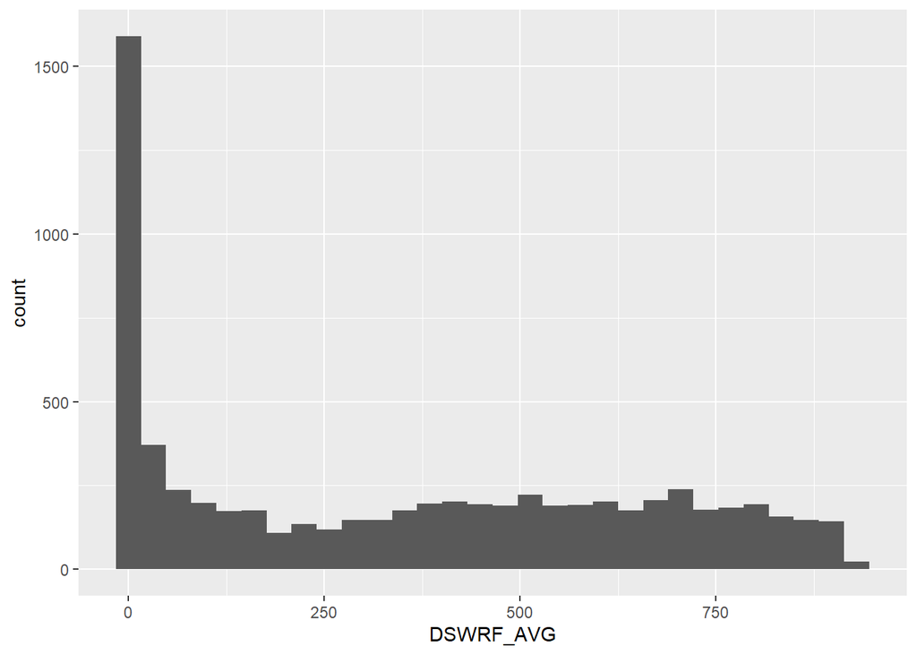

```r
ggplot(weather_production, aes(x=DSWRF_AVG)) + geom_histogram()
```

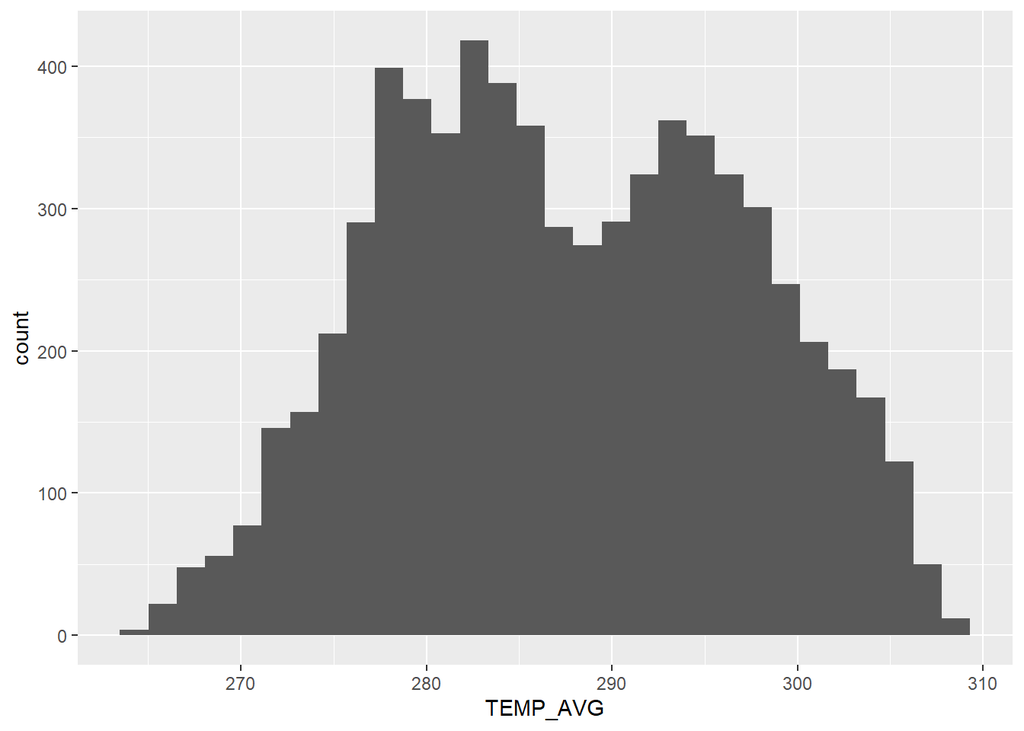

```r
ggplot(weather_production, aes(x=TEMP_AVG)) + geom_histogram()
```

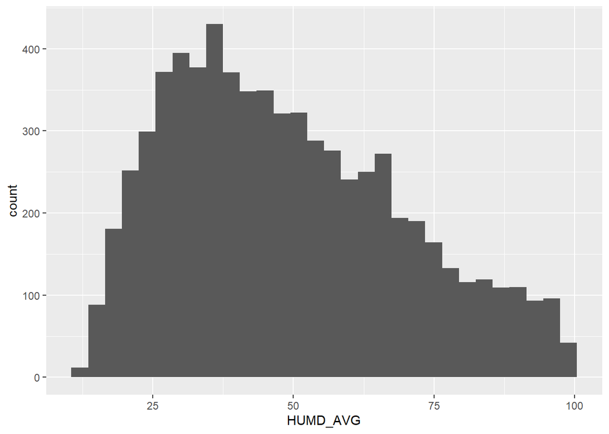

```r
ggplot(weather_production, aes(x=HUMD_AVG)) + geom_histogram()
```

##Boxplot of Target & Independent Variables

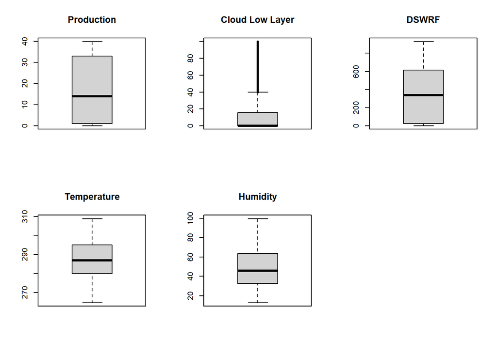

```r
par(mfrow=c(2,3))
boxplot(weather_production$production, main = "Production")
boxplot(weather_production$CLOUD_LOW_LAYER_AVG, main = "Cloud Low Layer")
boxplot(weather_production$DSWRF_AVG, main = "DSWRF")
boxplot(weather_production$TEMP_AVG, main = "Temperature")
boxplot(weather_production$HUMD_AVG, main = "Humidity")
par(mfrow=c(1,1))
```

##Scatterplots

Scatter plot of Cloud Low Layer vs Production values is shown below. We can observe that higher cloud low layer values causes lower frequency for high production values.

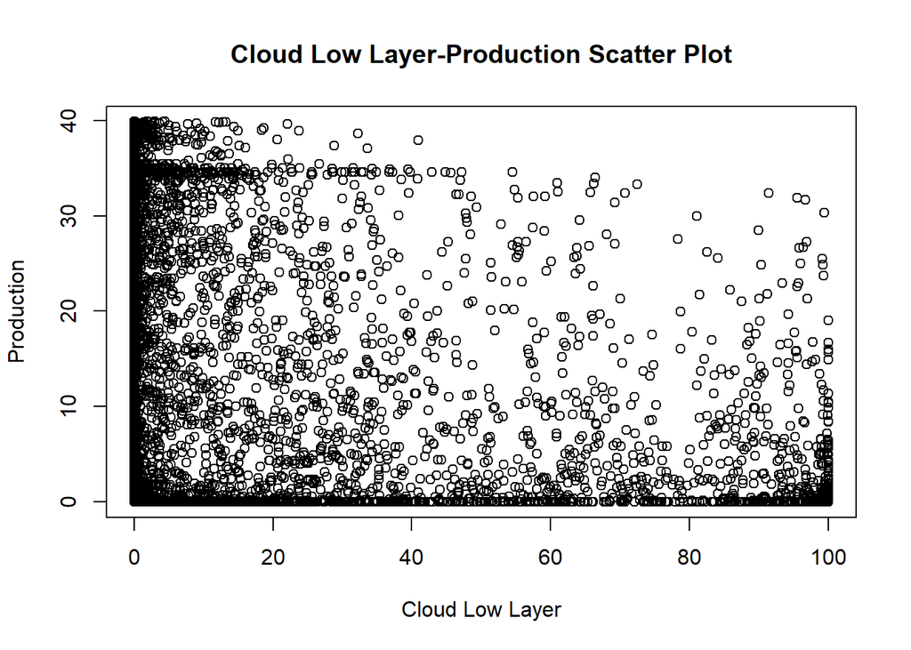

```r
plot(weather_production$CLOUD_LOW_LAYER_AVG, weather_production$production, xlab = "Cloud Low Layer", ylab = "Production", main = "Cloud Low Layer-Production Scatter Plot")
```

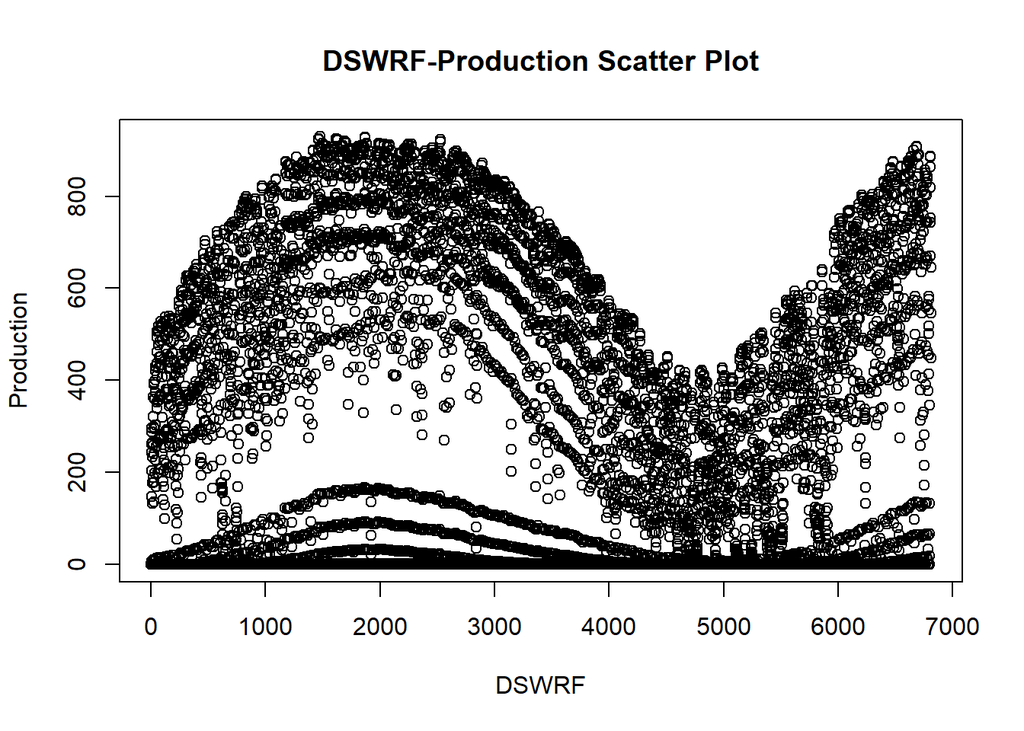

```r
plot(weather_production$DSWRF_AVG, weather_production$Production, xlab = "DSWRF", ylab = "Production", main = "DSWRF-Production Scatter Plot")
```

Scatter plot of Hour vs DSWRF values is shown below. There is a relationship between DSWRF values and hours similar to the relation of Production-Hour.

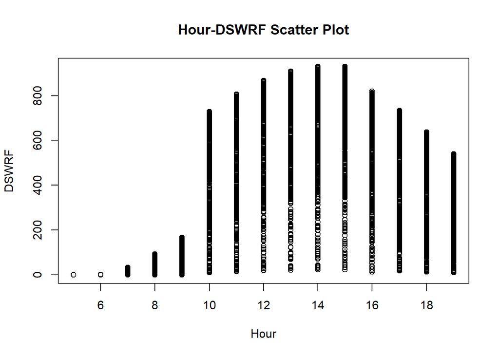

```r
plot(weather_production$hour.x, weather_production$DSWRF_AVG , xlab = "Hour", ylab = "DSWRF", main = "Hour-DSWRF Scatter Plot")
```

Scatter plot of Hour vs Temperature values is shown below. As it is expected, temperature are higher at afternoon hours and lower at morning and evening hours

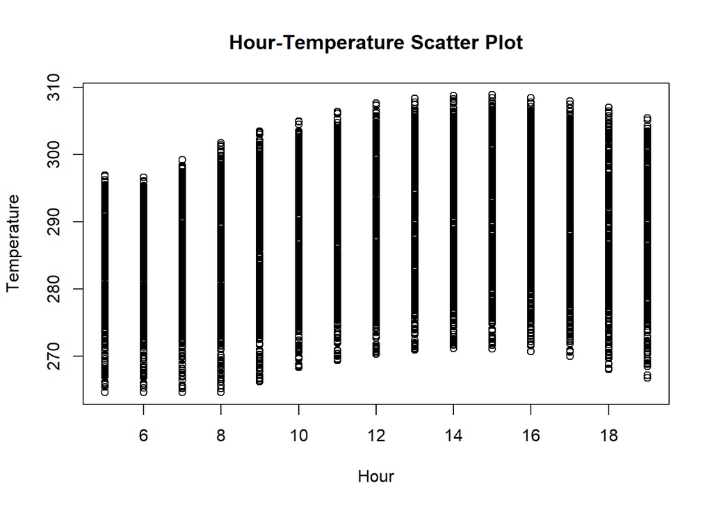

```r
plot(weather_production$hour.x, weather_production$TEMP_AVG, xlab = "Hour", ylab = "Temperature", main = "Hour-Temperature Scatter Plot")
```

Scatter plot of DSWRF vs Temperature values is shown below. It is obvious that low temperature values correspond to low DSWRF values, while the higher DSWRF values, the slightly higher the temperature values.

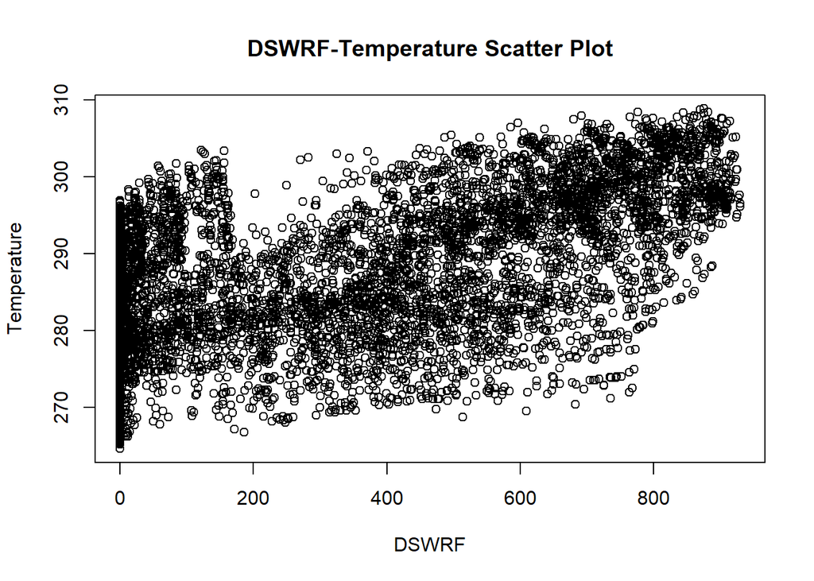

```r
plot(weather_production$DSWRF_AVG, weather_production$TEMP_AVG , xlab = "DSWRF", ylab = "Temperature", main = "DSWRF-Temperature Scatter Plot")
```

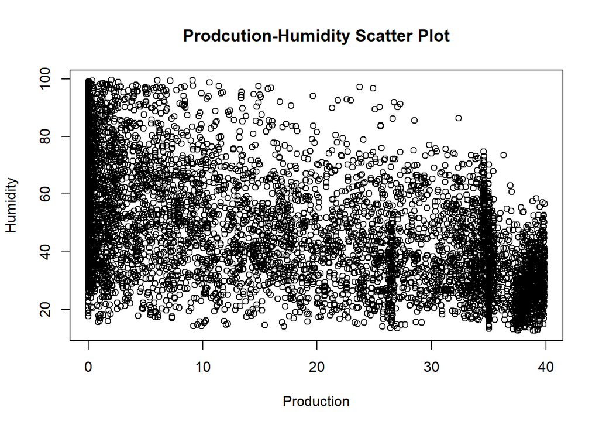

```r
plot(weather_production$production, weather_production$HUMD_AVG , xlab = "Production", ylab = "Humidity", main = "Prodcution-Humidity Scatter Plot")
```

Scatter plot of Humidity vs Cloud Low Layer values is shown below. We can say that Humidity & Cloud Low Layer are positively related to each other. So indirectly humidity is affected production as well.

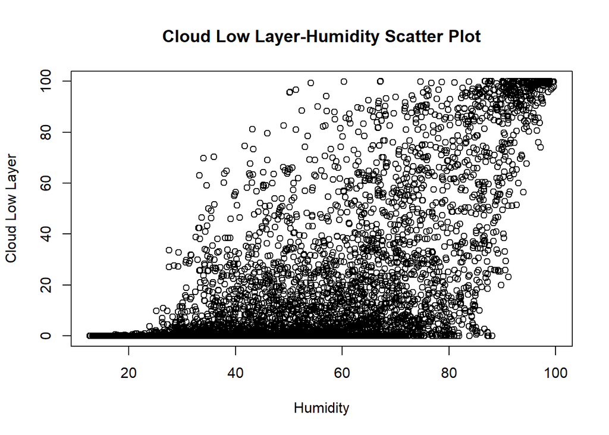

```r
plot(weather_production$HUMD_AVG, weather_production$CLOUD_LOW_LAYER_AVG , xlab = "Humidity", ylab = "Cloud Low Layer", main = "Cloud Low Layer-Humidity Scatter Plot")
```

##Lineplots

Line plot of Production as a time series for each hour is shown below. We can observe that there is seasonal effect on the production for morning and evening hours as the day hours are shifting along the year.

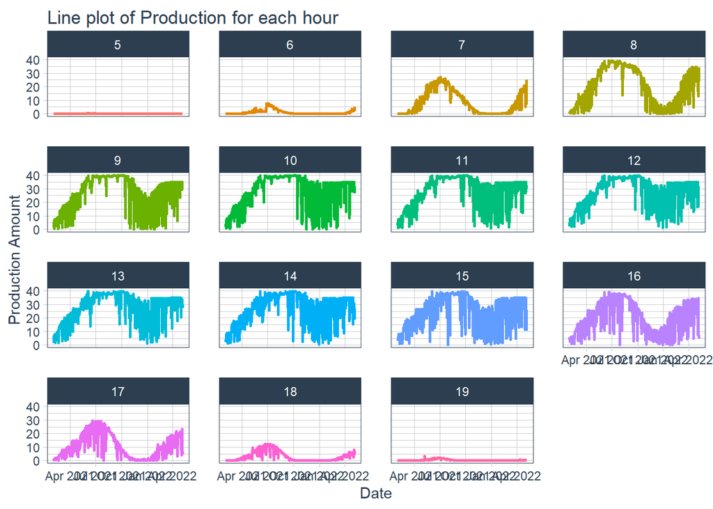

```r
weather_production %>%
  ggplot(aes(x = date.x, y = production)) +
  geom_line(aes(color = as.factor(hour.x)), size = 0.9, show.legend = F) +
  labs(title="Line plot of Production for each hour", y="Production Amount", x="Date") +
  facet_wrap(~hour.x, ncol=4) +
  theme_tq()
```

Line plot of Temperature as a time series for each hour is shown below. We can also observe the same seasonal effect on the temperature variable. Temperature is low at winter and autumn months, while it is higher in summer and spring months (as expected).

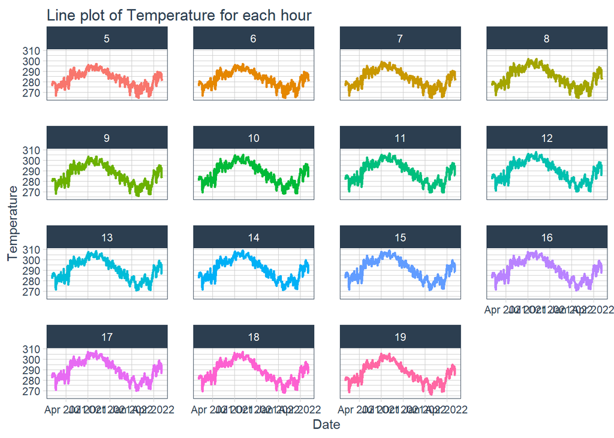

```r
weather_production %>%
  ggplot(aes(x = date.x, y = TEMP_AVG)) +
  geom_line(aes(color = as.factor(hour.x)), size = 0.9, show.legend = F) +
  labs(title="Line plot of Temperature for each hour", y="Temperature", x="Date") +
  facet_wrap(~hour.x, ncol=4) +
  theme_tq()
```

Line plot of DSWRF as a time series for each hour is shown below. We can see the same seasonal effect with temperature variable. However, DSWRF values are almost zero in morning hours.

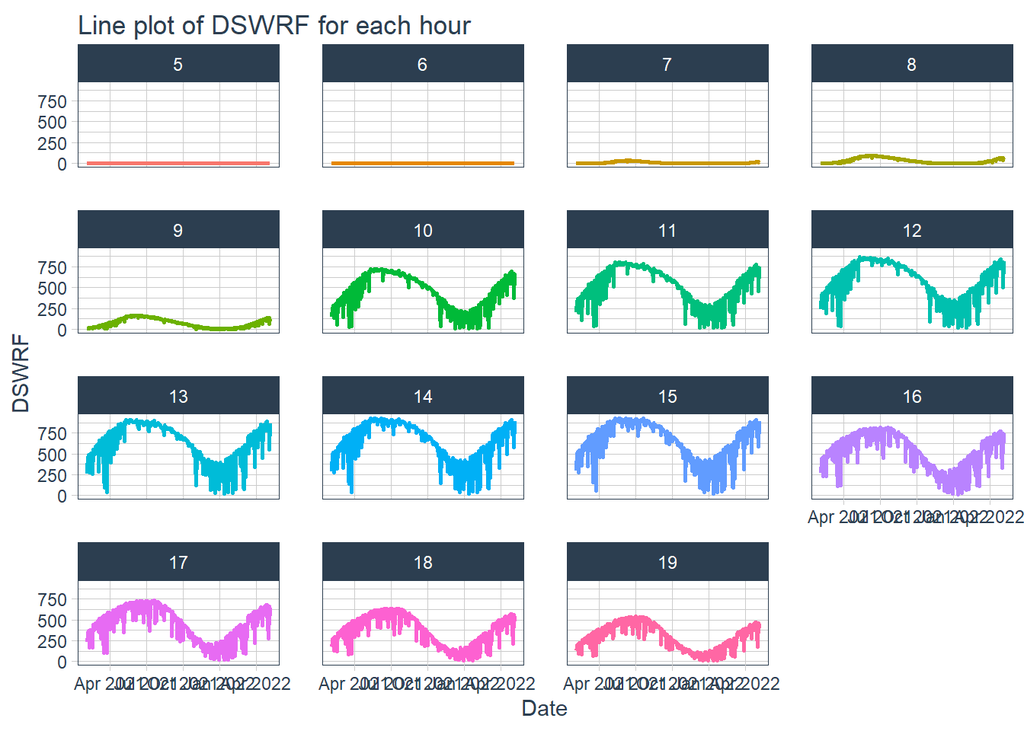

```r
weather_production %>%
  ggplot(aes(x = date.x, y = DSWRF_AVG)) +
  geom_line(aes(color = as.factor(hour.x)), size = 0.9, show.legend = F) +
  labs(title="Line plot of DSWRF for each hour", y="DSWRF", x="Date") +
  facet_wrap(~hour.x, ncol=4) +
  theme_tq()
```

Line plot of Cloud Low Layer as a time series for each hour is shown below. We can state that there are very few cloudy days at summer months (as expected).

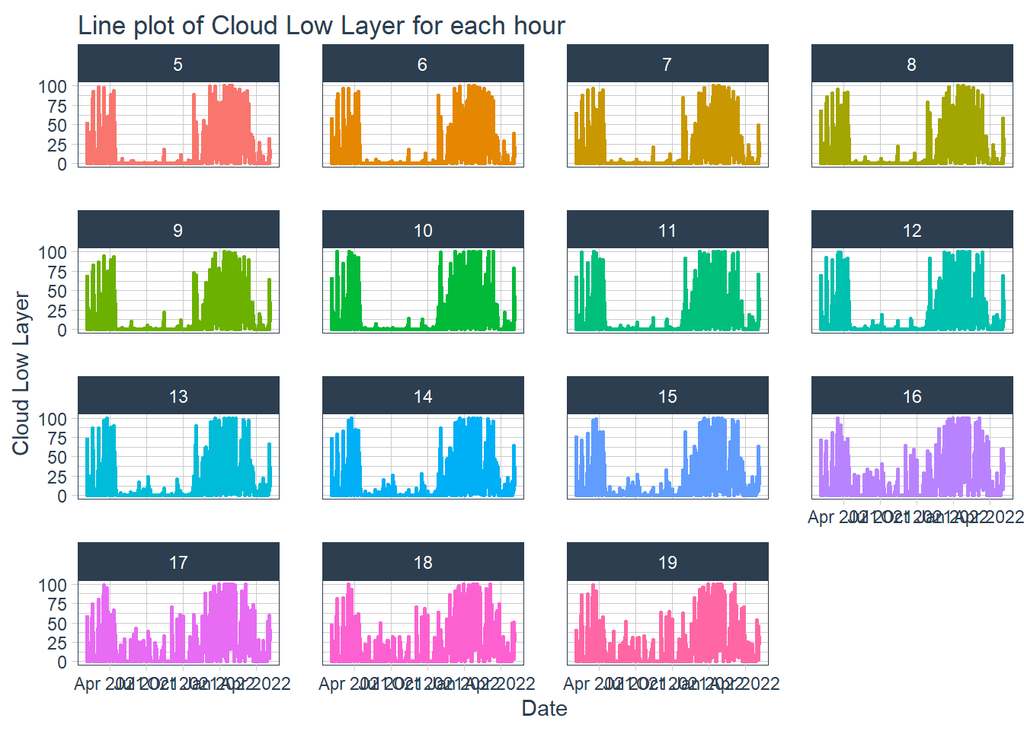

```r
weather_production %>%
  ggplot(aes(x = date.x, y = CLOUD_LOW_LAYER_AVG)) +
  geom_line(aes(color = as.factor(hour.x)), size = 0.9, show.legend = F) +
  labs(title="Line plot of Cloud Low Layer for each hour", y="Cloud Low Layer", x="Date") +
  facet_wrap(~hour.x, ncol=4) +
  theme_tq()
```

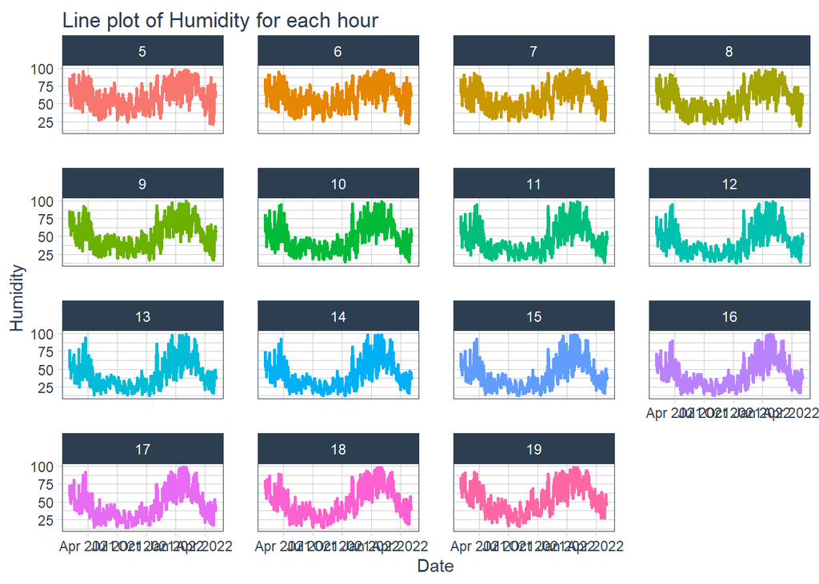

```r
weather_production %>%
  ggplot(aes(x = date.x, y = HUMD_AVG)) +
  geom_line(aes(color = as.factor(hour.x)), size = 0.9, show.legend = F) +
  labs(title="Line plot of Humidity for each hour", y="Humidity", x="Date") +
  facet_wrap(~hour.x, ncol=4) +
  theme_tq()
```

##Pairwise Correlations

Pairwise correlation of independent variables & dependent variable is shown below. We can state that production is positively correlated to DSWRF & TEMP, while negative correlated with HUMD & Cloud Layers.

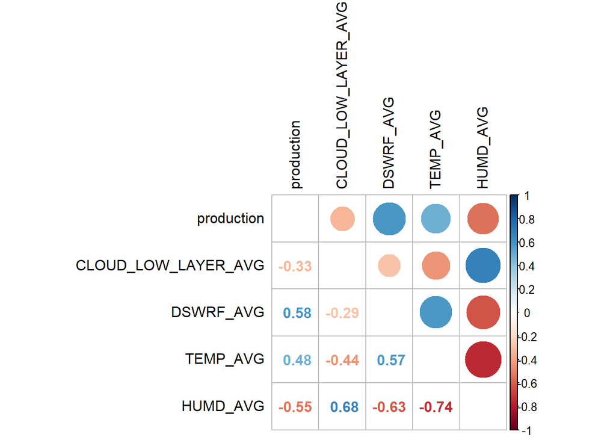

```r
#install.packages("corrplot")
library(corrplot)
cor_numVar <- cor(weather_production[,c(3,7,8,9,10)], use="pairwise.complete.obs")
corrplot.mixed(cor_numVar, tl.col="black", tl.pos = "lt")
```

##Tuning

Finding the largest mean production level for the whole data to use that hour for parameter tuning and use the same parameters for other hours. Hour **11** or **12** can be used for parameter tuning.

```r
weather_production %>% group_by(hour.x) %>%  summarise(mean_production = mean(production)) %>% arrange(desc(mean_production))
```

```
## # A tibble: 15 × 2
##    hour.x mean_production
##     <int>           <dbl>
##  1     11         27.9
##  2     12         27.8
##  3     10         27.7
##  4     13         27.6
##  5     14         26.4
##  6      9         26.0
##  7     15         24.4
##  8      8         20.0
##  9     16         19.8
## 10     17         10.5
## 11      7          8.39
## 12     18          2.94
## 13      6          1.01
## 14     19          0.296
## 15      5          0.0251
```

#Data Manipulation

##Lagging

Lag arranged different time of day, fromm 1 to 168 hour with different time series like (1 Hour, 6 Hour, 12 Hour, 24 Hour, 48 Hour, 168 Hour (one week))

```r
## 1 Hour Lag
weather_production$Production1hourlag  = lag(weather_production$production, 1)
weather_production$Cloud1hourlag  = lag(weather_production$CLOUD_LOW_LAYER_AVG, 1)
weather_production$Dswrf1hourlag  = lag(weather_production$DSWRF_AVG, 1)
weather_production$Temp1hourlag  = lag(weather_production$TEMP_AVG, 1)
weather_production$Humidity1hourlag  = lag(weather_production$HUMD_AVG, 1)

## 6 Hour Lag
weather_production$Production6hourlag  = lag(weather_production$production, 6)
weather_production$Cloud6hourlag  = lag(weather_production$CLOUD_LOW_LAYER_AVG, 6)
weather_production$Dswrf6hourlag  = lag(weather_production$DSWRF_AVG, 6)
weather_production$Temp6hourlag  = lag(weather_production$TEMP_AVG, 6)
weather_production$Humidity6hourlag  = lag(weather_production$HUMD_AVG, 6)

## 12 Hour Lag
weather_production$Production12hourlag  = lag(weather_production$production, 12)
weather_production$Cloud12hourlag  = lag(weather_production$CLOUD_LOW_LAYER_AVG, 12)
weather_production$Dswrf12hourlag  = lag(weather_production$DSWRF_AVG, 12)
weather_production$Temp12hourlag  = lag(weather_production$TEMP_AVG, 12)
weather_production$Humidity12hourlag  = lag(weather_production$HUMD_AVG, 12)


## 24 Hour Lag
weather_production$Production24hourlag  = lag(weather_production$production, 24)
weather_production$Cloud24hourlag  = lag(weather_production$CLOUD_LOW_LAYER_AVG, 24)
weather_production$Dswrf24hourlag  = lag(weather_production$DSWRF_AVG, 24)
weather_production$Temp24hourlag  = lag(weather_production$TEMP_AVG, 24)
weather_production$Humidity24hourlag  = lag(weather_production$HUMD_AVG, 24)

## 48 Hour Lag
weather_production$Production48hourlag  = lag(weather_production$production, 48)
weather_production$Cloud48hourlag  = lag(weather_production$CLOUD_LOW_LAYER_AVG, 48)
weather_production$Dswrf48hourlag  = lag(weather_production$DSWRF_AVG, 48)
weather_production$Temp48hourlag  = lag(weather_production$TEMP_AVG, 48)
weather_production$Humidity48hourlag  = lag(weather_production$HUMD_AVG, 48)

## 168 Hour Lag
weather_production$Production168hourlag  = lag(weather_production$production, 168)
weather_production$Cloud168hourlag  = lag(weather_production$CLOUD_LOW_LAYER_AVG, 168)
weather_production$Dswrf168hourlag  = lag(weather_production$DSWRF_AVG, 168)
weather_production$Temp168hourlag  = lag(weather_production$TEMP_AVG, 168)
weather_production$Humidity168hourlag  = lag(weather_production$HUMD_AVG, 168)


weather_production$Production3hourMA  = rollmean(weather_production$TEMP_AVG, 3,na.pad = T, align = "right")
weather_production$Dswrf3hourMA  = rollmean(weather_production$TEMP_AVG, 3,na.pad = T, align = "right")
weather_production$Temp3hourMA  = rollmean(weather_production$TEMP_AVG, 3,na.pad = T, align = "right")

weather_production$Production24hourMA  = rollmean(weather_production$TEMP_AVG, 24,na.pad = T, align = "right")
weather_production$Cloud24hourMA  = rollmean(weather_production$TEMP_AVG, 24,na.pad = T, align = "right")
weather_production$Dswrf24hourMA  = rollmean(weather_production$TEMP_AVG, 24,na.pad = T, align = "right")
weather_production$Temp24hourMA  = rollmean(weather_production$TEMP_AVG, 24,na.pad = T, align = "right")

weather_production$Production48hourMA  = rollmean(weather_production$TEMP_AVG, 48,na.pad = T, align = "right")
weather_production$Cloud48hourMA  = rollmean(weather_production$TEMP_AVG, 48,na.pad = T, align = "right")
weather_production$Dswrf48hourMA  = rollmean(weather_production$TEMP_AVG, 48,na.pad = T, align = "right")
weather_production$Temp48hourMA  = rollmean(weather_production$TEMP_AVG, 48,na.pad = T, align = "right")

weather_production$Production168hourMA  = rollmean(weather_production$TEMP_AVG, 168,na.pad = T, align = "right")
weather_production$Cloud168hourMA  = rollmean(weather_production$TEMP_AVG, 168,na.pad = T, align = "right")
weather_production$Dswrf168hourMA  = rollmean(weather_production$TEMP_AVG, 168,na.pad = T, align = "right")
weather_production$Temp168hourMA  = rollmean(weather_production$TEMP_AVG, 168,na.pad = T, align = "right")


weather_production = weather_production[complete.cases(weather_production), ]
head(weather_production)
```

```
##        date.x hour.x production           timestamp     date.y hour.y
## 1: 2021-02-12      8       1.95 2021-02-12 08:00:00 2021-02-12      8
## 2: 2021-02-12      9       6.14 2021-02-12 09:00:00 2021-02-12      9
## 3: 2021-02-12     10       7.37 2021-02-12 10:00:00 2021-02-12     10
## 4: 2021-02-12     11       7.65 2021-02-12 11:00:00 2021-02-12     11
## 5: 2021-02-12     12       5.00 2021-02-12 12:00:00 2021-02-12     12
## 6: 2021-02-12     13       3.52 2021-02-12 13:00:00 2021-02-12     13
##    CLOUD_LOW_LAYER_AVG DSWRF_AVG TEMP_AVG HUMD_AVG Production1hourlag
## 1:            25.77778    0.0000 278.6807 90.54444               0.00
## 2:            23.33333   17.0000 281.0468 83.62222               1.95
## 3:            21.11111  255.5556 282.1482 75.92222               6.14
## 4:            18.88889  347.7778 283.0642 69.42222               7.37
## 5:            15.33333  426.6667 284.0552 61.90000               7.65
## 6:            11.55556  483.3333 284.6796 58.68889               5.00
##    Cloud1hourlag Dswrf1hourlag Temp1hourlag Humidity1hourlag Production6hourlag
```

[output cut: 69 more lines]

##Train and test data sets

```r
weather_production_train<- weather_production %>% filter(date.x < as_date('2021-12-31'))
weather_production_test <- weather_production %>% filter(date.x >= as_date('2022-01-01') & date.x <= as_date('2022-02-28'))
```

Splitting train data into hourly format to have different models for every hour

```r
weather_production_train_h5 <- weather_production_train %>% filter(hour.x == 5)
weather_production_train_h6 <- weather_production_train %>% filter(hour.x == 6)
weather_production_train_h7 <- weather_production_train %>% filter(hour.x == 7)
weather_production_train_h8 <- weather_production_train %>% filter(hour.x == 8)
weather_production_train_h9 <- weather_production_train %>% filter(hour.x == 9)
weather_production_train_h10 <- weather_production_train %>% filter(hour.x == 10)
weather_production_train_h11 <- weather_production_train %>% filter(hour.x == 11)
weather_production_train_h12 <- weather_production_train %>% filter(hour.x == 12)
weather_production_train_h13 <- weather_production_train %>% filter(hour.x == 13)
weather_production_train_h14 <- weather_production_train %>% filter(hour.x == 14)
weather_production_train_h15 <- weather_production_train %>% filter(hour.x == 15)
weather_production_train_h16 <- weather_production_train %>% filter(hour.x == 16)
weather_production_train_h17 <- weather_production_train %>% filter(hour.x == 17)
weather_production_train_h18 <- weather_production_train %>% filter(hour.x == 18)
weather_production_train_h19 <- weather_production_train %>% filter(hour.x == 19)
```

Splitting test data into hourly format to have different models for every hour

```r
weather_production_test_h5 <- weather_production_test %>% filter(hour.x == 5)
weather_production_test_h6 <- weather_production_test %>% filter(hour.x == 6)
weather_production_test_h7 <- weather_production_test %>% filter(hour.x == 7)
weather_production_test_h8 <- weather_production_test %>% filter(hour.x == 8)
weather_production_test_h9 <- weather_production_test %>% filter(hour.x == 9)
weather_production_test_h10 <- weather_production_test %>% filter(hour.x == 10)
weather_production_test_h11 <- weather_production_test %>% filter(hour.x == 11)
weather_production_test_h12 <- weather_production_test %>% filter(hour.x == 12)
weather_production_test_h13 <- weather_production_test %>% filter(hour.x == 13)
weather_production_test_h14 <- weather_production_test %>% filter(hour.x == 14)
weather_production_test_h15 <- weather_production_test %>% filter(hour.x == 15)
weather_production_test_h16 <- weather_production_test %>% filter(hour.x == 16)
weather_production_test_h17 <- weather_production_test %>% filter(hour.x == 17)
weather_production_test_h18 <- weather_production_test %>% filter(hour.x == 18)
weather_production_test_h19 <- weather_production_test %>% filter(hour.x == 19)
```

#Modelling

Different models such as linear regression, decision tree, random forest, GLMNET are tried for data set of Hour 11 to make the parameter tuning on the data.

```r
fitControl <- trainControl(method = "repeatedcv",
                           number = 5,
                           repeats = 5)
```

```r
lin_reg_h11 <- train(production ~ .,
                 data = weather_production_train_h11 %>% select(-date.x, -hour.x),
                 method = "lm",
                 trControl = fitControl,
                 tuneLength = 5)
lin_reg_h11
```

```
## Linear Regression
##
## 318 samples
##  52 predictor
##
## No pre-processing
## Resampling: Cross-Validated (5 fold, repeated 5 times)
## Summary of sample sizes: 254, 255, 254, 254, 255, 254, ...
## Resampling results:
##
##   RMSE      Rsquared  MAE
##   3.799545  0.883693  2.337539
##
## Tuning parameter 'intercept' was held constant at a value of TRUE
```

```r
summary(lin_reg_h11)
```

```
##
## Call:
## lm(formula = .outcome ~ ., data = dat)
##
## Residuals:
##      Min       1Q   Median       3Q      Max
## -20.8348  -0.9004   0.1823   1.1622  14.8538
##
## Coefficients: (14 not defined because of singularities)
##                        Estimate Std. Error t value Pr(>|t|)
## (Intercept)          -2.275e+02  1.100e+02  -2.069   0.0395 *
## timestamp             1.460e-07  6.779e-08   2.154   0.0321 *
## date.y                       NA         NA      NA       NA
## hour.y                       NA         NA      NA       NA
## CLOUD_LOW_LAYER_AVG  -6.244e-03  8.914e-02  -0.070   0.9442
## DSWRF_AVG            -3.004e-02  2.319e-02  -1.295   0.1964
## TEMP_AVG              8.121e-01  1.360e+00   0.597   0.5509
## HUMD_AVG              8.651e-02  1.949e-01   0.444   0.6575
## Production1hourlag    6.299e-01  3.853e-02  16.347   <2e-16 ***
## Cloud1hourlag        -3.876e-02  8.523e-02  -0.455   0.6496
## Dswrf1hourlag         2.666e-02  2.437e-02   1.094   0.2750
## Temp1hourlag         -2.977e+00  2.930e+00  -1.016   0.3104
## Humidity1hourlag     -1.623e-01  2.058e-01  -0.789   0.4310
## Production6hourlag   -3.008e+00  7.022e+00  -0.428   0.6688
## Cloud6hourlag        -4.375e-02  1.805e-02  -2.424   0.0160 *
## Dswrf6hourlag                NA         NA      NA       NA
## Temp6hourlag          6.391e-01  3.618e-01   1.766   0.0784 .
## Humidity6hourlag      6.898e-02  4.195e-02   1.644   0.1013
## Production12hourlag   3.683e-02  3.671e-02   1.003   0.3166
## Cloud12hourlag        2.213e-02  2.372e-02   0.933   0.3516
## Dswrf12hourlag       -5.274e-03  4.407e-03  -1.197   0.2324
## Temp12hourlag        -6.909e-02  4.894e-01  -0.141   0.8878
## Humidity12hourlag    -7.256e-02  4.707e-02  -1.542   0.1243
## Production24hourlag   4.001e-02  5.545e-02   0.722   0.4711
## Cloud24hourlag        8.090e-03  1.795e-02   0.451   0.6525
## Dswrf24hourlag        6.220e-04  4.946e-03   0.126   0.9000
## Temp24hourlag         5.007e-01  3.441e-01   1.455   0.1468
## Humidity24hourlag    -1.720e-02  3.373e-02  -0.510   0.6105
## Production48hourlag   1.494e-02  4.648e-02   0.321   0.7482
## Cloud48hourlag       -1.270e-03  1.442e-02  -0.088   0.9299
```

[output cut: 14 more lines]

```
## Temp24hourMA                 NA         NA      NA       NA
## Production48hourMA   -4.078e-01  8.019e-01  -0.509   0.6115
## Cloud48hourMA                NA         NA      NA       NA
## Dswrf48hourMA                NA         NA      NA       NA
## Temp48hourMA                 NA         NA      NA       NA
## Production168hourMA   2.805e-02  1.629e-01   0.172   0.8634
## Cloud168hourMA               NA         NA      NA       NA
## Dswrf168hourMA               NA         NA      NA       NA
## Temp168hourMA                NA         NA      NA       NA
## ---
## Signif. codes:  0 '***' 0.001 '**' 0.01 '*' 0.05 '.' 0.1 ' ' 1
##
## Residual standard error: 3.425 on 279 degrees of freedom
## Multiple R-squared:  0.917,  Adjusted R-squared:  0.9057
## F-statistic: 81.17 on 38 and 279 DF,  p-value: < 2.2e-16
```

```r
lin_reg_h11$finalModel
```

```
##
## Call:
## lm(formula = .outcome ~ ., data = dat)
##
## Coefficients:
##          (Intercept)             timestamp                date.y
##           -2.275e+02             1.460e-07                    NA
##               hour.y   CLOUD_LOW_LAYER_AVG             DSWRF_AVG
##                   NA            -6.244e-03            -3.004e-02
##             TEMP_AVG              HUMD_AVG    Production1hourlag
##            8.121e-01             8.651e-02             6.299e-01
##        Cloud1hourlag         Dswrf1hourlag          Temp1hourlag
##           -3.876e-02             2.666e-02            -2.977e+00
##     Humidity1hourlag    Production6hourlag         Cloud6hourlag
##           -1.623e-01            -3.008e+00            -4.375e-02
##        Dswrf6hourlag          Temp6hourlag      Humidity6hourlag
##                   NA             6.391e-01             6.898e-02
##  Production12hourlag        Cloud12hourlag        Dswrf12hourlag
##            3.683e-02             2.213e-02            -5.274e-03
##        Temp12hourlag     Humidity12hourlag   Production24hourlag
##           -6.909e-02            -7.256e-02             4.001e-02
##       Cloud24hourlag        Dswrf24hourlag         Temp24hourlag
##            8.090e-03             6.220e-04             5.007e-01
##    Humidity24hourlag   Production48hourlag        Cloud48hourlag
##           -1.720e-02             1.494e-02            -1.270e-03
##       Dswrf48hourlag         Temp48hourlag     Humidity48hourlag
##            4.545e-02             3.737e-02            -1.323e-02
## Production168hourlag       Cloud168hourlag       Dswrf168hourlag
##            2.920e-02             1.027e-02             1.324e-02
##       Temp168hourlag    Humidity168hourlag     Production3hourMA
##            3.700e-02             4.733e-03             2.126e+00
##         Dswrf3hourMA           Temp3hourMA    Production24hourMA
##                   NA                    NA            -6.966e-01
##        Cloud24hourMA         Dswrf24hourMA          Temp24hourMA
##                   NA                    NA                    NA
##   Production48hourMA         Cloud48hourMA         Dswrf48hourMA
##           -4.078e-01                    NA                    NA
##         Temp48hourMA   Production168hourMA        Cloud168hourMA
##                   NA             2.805e-02                    NA
##       Dswrf168hourMA         Temp168hourMA
##                   NA                    NA
```

##Decision Tree

```r
dec_tree_h11 <- train(production ~ .,
                  data = weather_production_train_h11 %>% select(-date.x, -hour.x),
                  method = "rpart",
                  trControl = fitControl,
                  tuneLength = 5)
dec_tree_h11
```

```
## CART
##
## 318 samples
##  52 predictor
##
## No pre-processing
## Resampling: Cross-Validated (5 fold, repeated 5 times)
## Summary of sample sizes: 254, 255, 254, 255, 254, 254, ...
## Resampling results across tuning parameters:
##
##   cp          RMSE      Rsquared   MAE
##   0.01808137  4.499845  0.8386492  2.850723
##   0.01823505  4.507847  0.8379511  2.877645
##   0.05976483  4.991261  0.7997852  3.534966
##   0.09445721  5.421276  0.7620192  3.965621
##   0.70197644  8.888583  0.6281017  7.276676
##
## RMSE was used to select the optimal model using the smallest value.
## The final value used for the model was cp = 0.01808137.
```

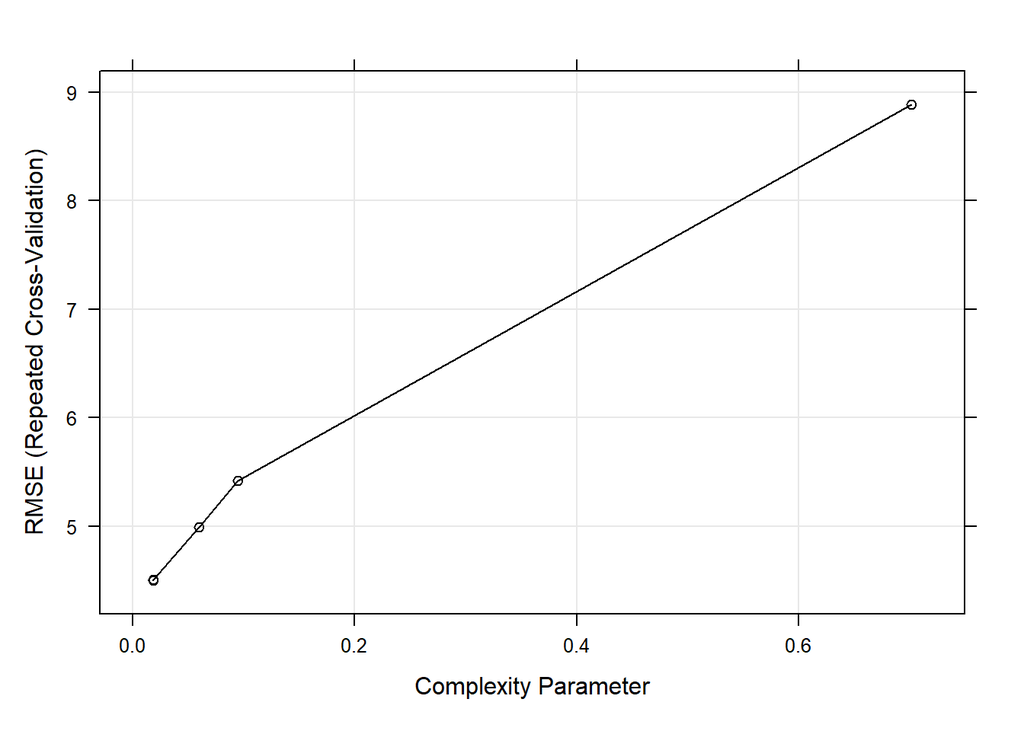

```r
trellis.par.set(caretTheme())
plot(dec_tree_h11)
```

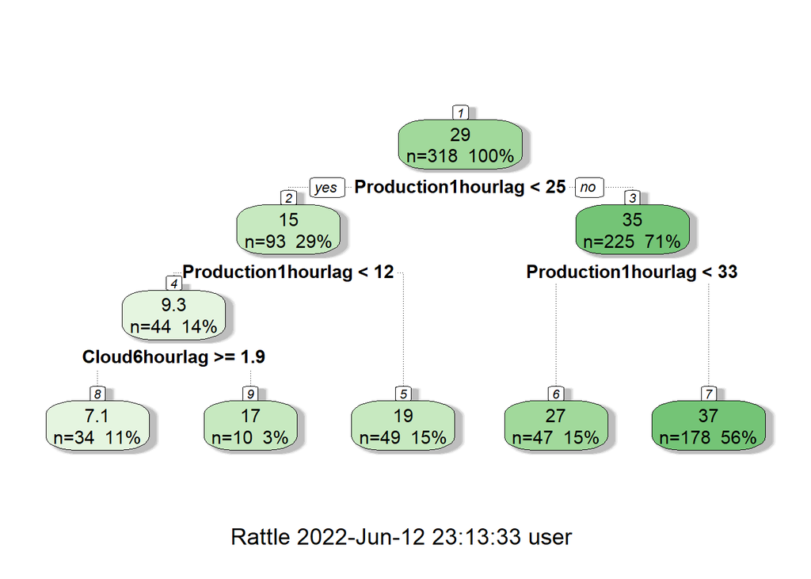

```r
fancyRpartPlot(dec_tree_h11$finalModel)
```

```r
dec_tree_h11$finalModel
```

```
## n= 318
##
## node), split, n, deviance, yval
##       * denotes terminal node
##
## 1) root 318 39448.1900 29.139470
##   2) Production1hourlag< 24.7585 93  5403.2550 14.624670
##     4) Production1hourlag< 11.646 44  1891.7440  9.311341
##       8) Cloud6hourlag>=1.855556 34   671.3068  7.118529 *
##       9) Cloud6hourlag< 1.855556 10   501.0968 16.766900 *
##     5) Production1hourlag>=11.646 49  1153.8970 19.395820 *
##   3) Production1hourlag>=24.7585 225  6353.2360 35.138920
##     6) Production1hourlag< 33.2935 47   866.8912 27.219360 *
##     7) Production1hourlag>=33.2935 178  1760.1780 37.230040 *
```

##Random Forest

Random Forest model with repeated cross validation (fitControl) is created by using caret package (“ranger” method). Impurity measure is used as an importance criteria and number of trees parameter is selected as 50 because of performance issues. According to results, mtry parameter is tuned and set to **52**, splitrule parameter is tuned and set to “extratrees”, min.node.size parameter is tuned and set to **5**.

```r
rand_forest_h11 <- train(production ~ .,
                       data = weather_production_train_h11 %>% select(-date.x, -hour.x),
                       method = "ranger",
                       trControl = fitControl,
                       num.trees = 50,
                       importance = "impurity")
rand_forest_h11
```

```
## Random Forest
##
## 318 samples
##  52 predictor
##
## No pre-processing
## Resampling: Cross-Validated (5 fold, repeated 5 times)
## Summary of sample sizes: 255, 254, 255, 254, 254, 255, ...
## Resampling results across tuning parameters:
##
##   mtry  splitrule   RMSE      Rsquared   MAE
##    2    variance    5.209064  0.7877344  3.348660
##    2    extratrees  5.210277  0.7929326  3.501456
##   27    variance    3.838418  0.8822174  2.176382
##   27    extratrees  3.814010  0.8855374  2.255465
##   52    variance    3.799087  0.8850124  2.094515
##   52    extratrees  3.754996  0.8875268  2.106806
##
## Tuning parameter 'min.node.size' was held constant at a value of 5
## RMSE was used to select the optimal model using the smallest value.
## The final values used for the model were mtry = 52, splitrule = extratrees
##  and min.node.size = 5.
```

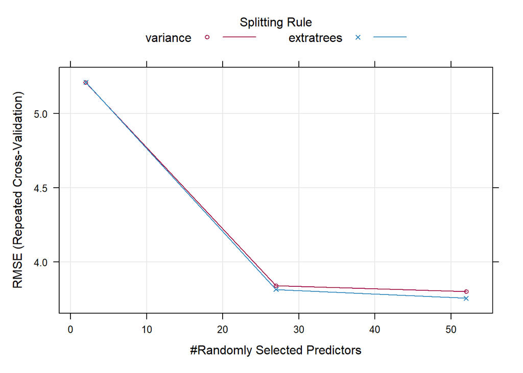

```r
plot(rand_forest_h11)
```

##GLMNET

GLMNET model with repeated cross validation (fitControl) is created by using caret package (“glmnet” method). According to results, alpha parameter is tuned and set to **0.55**, lambda parameter is tuned and set to **0.2097799**

```r
glmnet_h11 <- train(production ~ .,
                         data = weather_production_train_h11 %>% select(-date.x, -hour.x),
                         method = "glmnet",
                         trControl = fitControl,
                         tuneLenght= 6)
glmnet_h11
```

```
## glmnet
##
## 318 samples
##  52 predictor
##
## No pre-processing
## Resampling: Cross-Validated (5 fold, repeated 5 times)
## Summary of sample sizes: 254, 255, 255, 254, 254, 254, ...
## Resampling results across tuning parameters:
##
##   alpha  lambda      RMSE      Rsquared   MAE
##   0.10   0.02097799  3.684389  0.8894060  2.227521
##   0.10   0.20977988  3.568087  0.8956726  2.133628
##   0.10   2.09779883  3.747133  0.8901184  2.456429
##   0.55   0.02097799  3.637447  0.8918454  2.170057
##   0.55   0.20977988  3.485292  0.9001471  2.051550
##   0.55   2.09779883  3.975707  0.8941766  2.865047
##   1.00   0.02097799  3.595469  0.8940011  2.124792
##   1.00   0.20977988  3.493258  0.8996179  2.042174
##   1.00   2.09779883  4.276538  0.8886536  3.254149
##
## RMSE was used to select the optimal model using the smallest value.
## The final values used for the model were alpha = 0.55 and lambda = 0.2097799.
```

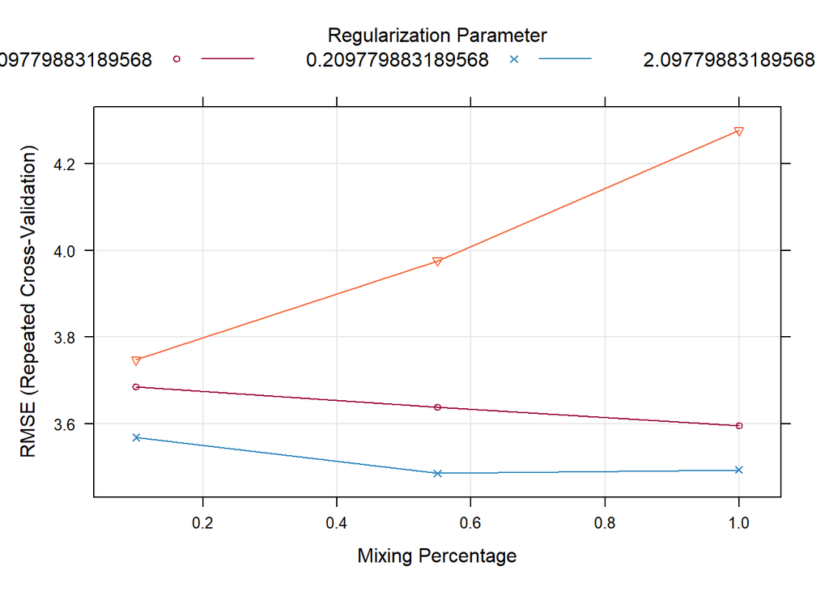

```r
plot(glmnet_h11)
```

##Model Comparison

```r
results = resamples(list(Linear_Regression = lin_reg_h11, Decision_Tree = dec_tree_h11, Random_Forest = rand_forest_h11, GLMNET = glmnet_h11))
summary(results)
```

```
##
## Call:
## summary.resamples(object = results)
##
## Models: Linear_Regression, Decision_Tree, Random_Forest, GLMNET
## Number of resamples: 25
##
## MAE
##                       Min.  1st Qu.   Median     Mean  3rd Qu.     Max. NA's
## Linear_Regression 1.647126 2.129507 2.402805 2.337539 2.544521 2.964193    0
## Decision_Tree     1.867496 2.574009 2.944222 2.850723 3.107362 3.500013    0
## Random_Forest     1.566359 1.933140 2.208514 2.106806 2.286929 2.532431    0
## GLMNET            1.541216 1.885343 2.038751 2.051550 2.277013 2.697946    0
##
## RMSE
##                       Min.  1st Qu.   Median     Mean  3rd Qu.     Max. NA's
## Linear_Regression 2.286073 3.338427 3.822624 3.799545 4.300229 4.994509    0
## Decision_Tree     3.227738 3.985611 4.557757 4.499845 4.938508 5.999810    0
## Random_Forest     2.447565 3.223834 3.881692 3.754996 4.228700 4.855899    0
## GLMNET            2.382339 2.924138 3.625297 3.485292 3.781805 4.600087    0
##
## Rsquared
##                        Min.   1st Qu.    Median      Mean   3rd Qu.      Max.
## Linear_Regression 0.7879764 0.8529522 0.8873481 0.8836930 0.9110766 0.9590273
## Decision_Tree     0.7444424 0.8010299 0.8408786 0.8386492 0.8745840 0.9218180
## Random_Forest     0.8128330 0.8662798 0.8883388 0.8875268 0.9095287 0.9631470
## GLMNET            0.8190854 0.8702278 0.8927080 0.9001471 0.9352994 0.9602330
##                   NA's
## Linear_Regression    0
## Decision_Tree        0
## Random_Forest        0
## GLMNET               0
```

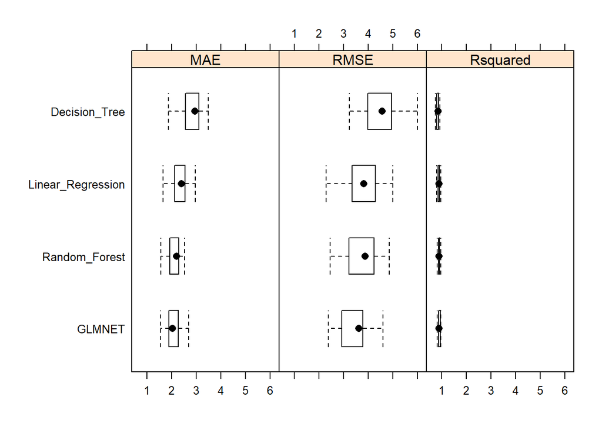

```r
bwplot(results)
```

##Modelling for each hour